# Untitled

```r
#Fit the PPP model
fit <- ppm(lupus_ppp ~ elev + I(forest_cover^2) + hfi + dis_water)
fit
```

```
## Nonstationary Poisson process
## Fitted to point pattern dataset 'lupus_ppp'
##
## Log intensity:  ~elev + I(forest_cover^2) + hfi + dis_water
##
## Fitted trend coefficients:
##       (Intercept)              elev I(forest_cover^2)               hfi
##     -2.022093e+01     -2.211025e-03      3.071059e-05      2.794585e+00
##         dis_water
##     -2.807036e-04
##
##                        Estimate         S.E.       CI95.lo       CI95.hi Ztest
## (Intercept)       -2.022093e+01 1.594381e-01 -2.053342e+01 -1.990843e+01   ***
## elev              -2.211025e-03 1.472386e-04 -2.499608e-03 -1.922443e-03   ***
## I(forest_cover^2)  3.071059e-05 1.884644e-05 -6.227760e-06  6.764894e-05
## hfi                2.794585e+00 2.853158e-01  2.235376e+00  3.353794e+00   ***
## dis_water         -2.807036e-04 5.180375e-05 -3.822371e-04 -1.791701e-04   ***
##                          Zval
## (Intercept)       -126.826198
## elev               -15.016619
## I(forest_cover^2)    1.629516
## hfi                  9.794708
## dis_water           -5.418596
## Problem:
##  Values of the covariates 'elev', 'forest_cover', 'hfi' were NA or undefined at
## 0.77% (17 out of 2194) of the quadrature points
```

```r
#Calculate the partial residuals as a function of elevation
par_res_elev <- parres(fit, "elev")
#Calculate the relative intensity as a function of cover
par_res_cover <- parres(fit, "forest_cover")
#Calculate the partial residuals as a function of elevation
par_res_hfi <- parres(fit, "hfi")
#Calculate the relative intensity as a function of cover
par_res_dist_water <- parres(fit, "dis_water")
```

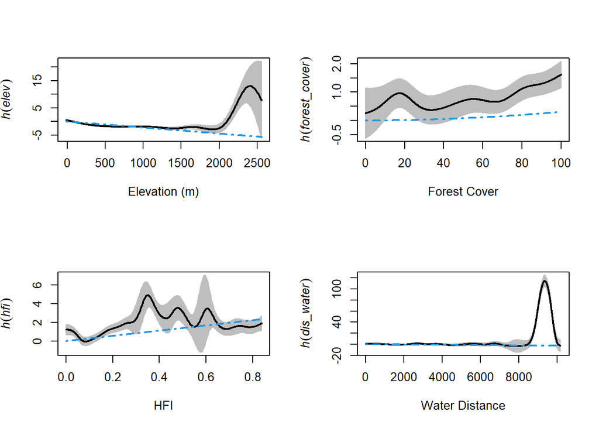

```r
par(mfrow = c(2, 2)) # Create a 2 x 2 plotting matrix
#Side by side plotting
plot(par_res_elev,
     legend = FALSE,
     lwd = 2,
     main = "",
     xlab = "Elevation (m)")
plot(par_res_cover,
     legend = FALSE,
     lwd = 2,
     main = "",
     xlab = "Forest Cover")
plot(par_res_hfi,
     legend = FALSE,
     lwd = 2,
     main = "",
     xlab = "HFI")
plot(par_res_dist_water,
     legend = FALSE,
     lwd = 2,
     main = "",
     xlab = "Water Distance")
```

```r
# NA with mean Forest Cover
mean_forest_cover <- mean(as.vector(as.matrix(forest_cover)), na.rm = TRUE)
forest_cover_clean <- eval.im(ifelse(is.na(forest_cover), mean_forest_cover, forest_cover))
# model
forest_cover_model <- ppm(lupus_ppp, ~ forest_cover, covariates = list(forest_cover = forest_cover_clean))

print(forest_cover_model)
```

```
## Nonstationary Poisson process
## Fitted to point pattern dataset 'lupus_ppp'
##
## Log intensity:  ~forest_cover
##
## Fitted trend coefficients:
##   (Intercept)  forest_cover
## -22.106816633   0.004210279
##
##                   Estimate        S.E.       CI95.lo       CI95.hi Ztest
## (Intercept)  -22.106816633 0.105086916 -22.312783204 -21.900850062   ***
## forest_cover   0.004210279 0.001590879   0.001092214   0.007328344    **
##                     Zval
## (Intercept)  -210.366975
## forest_cover    2.646512
```

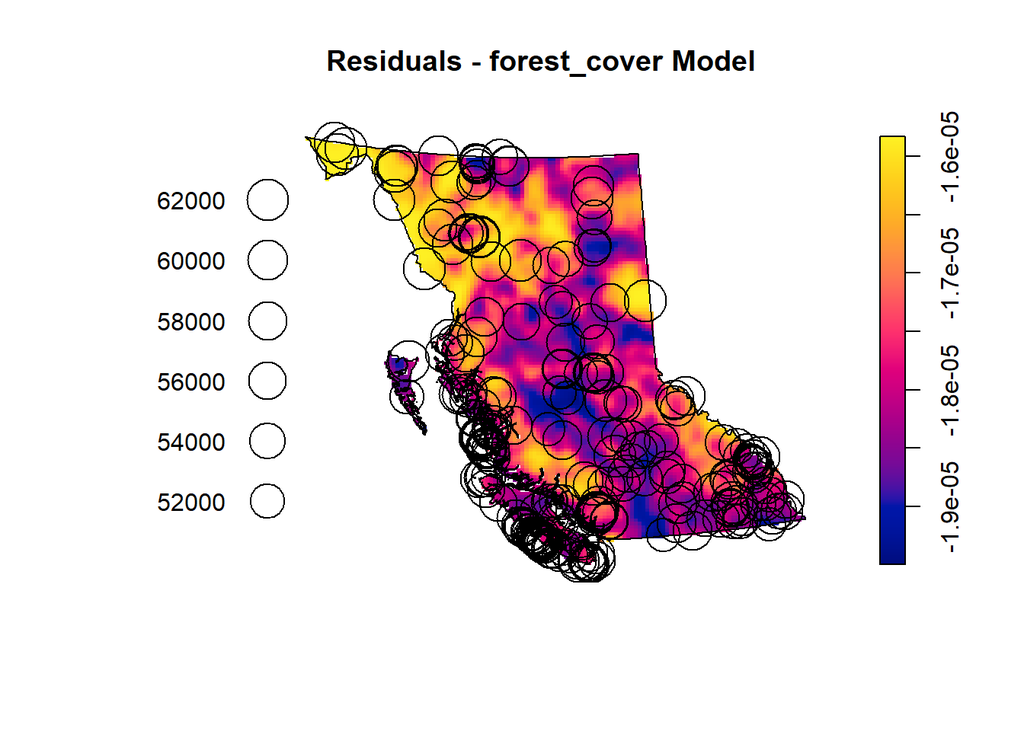

```r
forest_cover_residuals <- residuals(forest_cover_model, type = "pearson")
forest_cover_residuals$v[!is.finite(forest_cover_residuals$v)] <- NA
plot(forest_cover_residuals,
     main = "Residuals - forest_cover Model",
     na.col = "transparent")
```

```r
# NA with mean elevation
mean_elev <- mean(as.vector(as.matrix(elev)), na.rm = TRUE)
elev_clean <- eval.im(ifelse(is.na(elev), mean_elev, elev))
# model
elevation_model <- ppm(lupus_ppp, ~ elev, covariates = list(elev = elev_clean))
print(elevation_model)
```

```
## Nonstationary Poisson process
## Fitted to point pattern dataset 'lupus_ppp'
##
## Log intensity:  ~elev
##
## Fitted trend coefficients:
##   (Intercept)          elev
## -19.864456766  -0.002394505
##
##                  Estimate         S.E.       CI95.lo       CI95.hi Ztest
## (Intercept) -19.864456766 0.1033300919 -20.066980024 -19.661933507   ***
## elev         -0.002394505 0.0001407986  -0.002670465  -0.002118544   ***
##                  Zval
## (Intercept) -192.2427
## elev         -17.0066
```

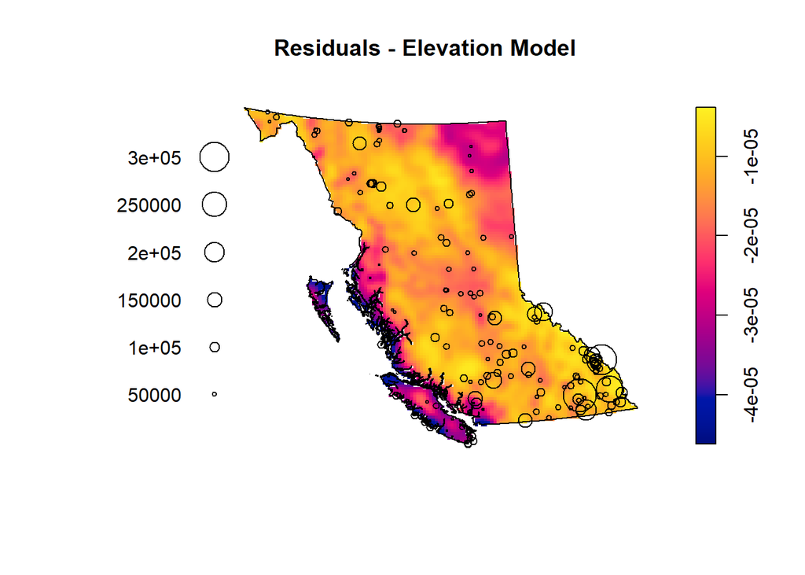

```r
Elevation_residuals <- residuals(elevation_model, type = "pearson")
Elevation_residuals$v[!is.finite(Elevation_residuals$v)] <- NA
plot(Elevation_residuals,
     main = "Residuals - Elevation Model",
     na.col = "transparent")
```

```r
# NA with mean hfi
mean_hfi <- mean(as.vector(as.matrix(hfi)), na.rm = TRUE)
hfi_clean <- eval.im(ifelse(is.na(hfi), mean_hfi, hfi))
# model
hfi_model <- ppm(lupus_ppp, ~ hfi, covariates = list(hfi = hfi_clean))
print(elevation_model)
```

```
## Nonstationary Poisson process
## Fitted to point pattern dataset 'lupus_ppp'
##
## Log intensity:  ~elev
##
## Fitted trend coefficients:
##   (Intercept)          elev
## -19.864456766  -0.002394505
##
##                  Estimate         S.E.       CI95.lo       CI95.hi Ztest
## (Intercept) -19.864456766 0.1033300919 -20.066980024 -19.661933507   ***
## elev         -0.002394505 0.0001407986  -0.002670465  -0.002118544   ***
##                  Zval
## (Intercept) -192.2427
## elev         -17.0066
```

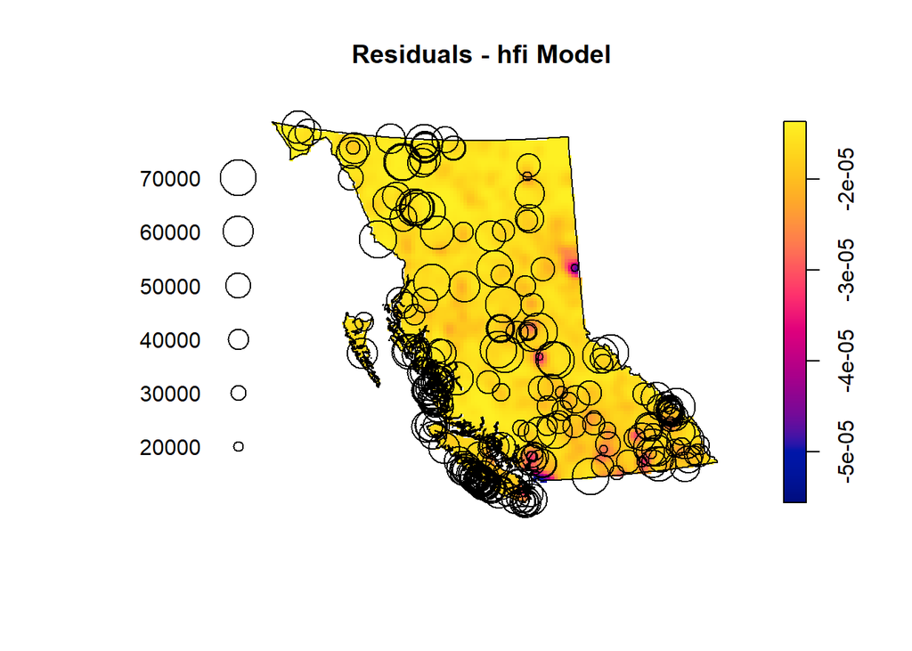

```r
hfi_residuals <- residuals(hfi_model, type = "pearson")
hfi_residuals$v[!is.finite(hfi_residuals$v)] <- NA
plot(hfi_residuals,
     main = "Residuals - hfi Model",
     na.col = "transparent")
```

```r
# NA with mean Forest Cover
mean_forest_cover <- mean(as.vector(as.matrix(forest_cover)), na.rm = TRUE)
forest_cover_clean <- eval.im(ifelse(is.na(forest_cover), mean_forest_cover, forest_cover))

# NA with mean elevation
mean_elev <- mean(as.vector(as.matrix(elev)), na.rm = TRUE)
elev_clean <- eval.im(ifelse(is.na(elev), mean_elev, elev))

# NA with mean HFI
mean_hfi <- mean(as.vector(as.matrix(hfi)), na.rm = TRUE)
hfi_clean <- eval.im(ifelse(is.na(hfi), mean_hfi, hfi))

# NA with mean Dis_Water
mean_dis_water <- mean(as.vector(as.matrix(dis_water)), na.rm = TRUE)
dis_water_clean <- eval.im(ifelse(is.na(dis_water), mean_dis_water, dis_water))
```

```r
clean_fit <- ppm(lupus_ppp ~ elev + I(forest_cover^2) + hfi + dis_water,
           data = list(elev = elev_clean,
                       forest_cover = forest_cover_clean,
                       hfi = hfi_clean,
                       dis_water = dis_water_clean))
clean_fit
```

```
## Nonstationary Poisson process
## Fitted to point pattern dataset 'lupus_ppp'
##
## Log intensity:  ~elev + I(forest_cover^2) + hfi + dis_water
##
## Fitted trend coefficients:
##       (Intercept)              elev I(forest_cover^2)               hfi
##     -2.015495e+01     -2.047795e-03      1.874981e-05      2.435619e+00
##         dis_water
##     -3.007940e-04
##
##                        Estimate         S.E.       CI95.lo       CI95.hi Ztest
## (Intercept)       -2.015495e+01 1.546081e-01 -2.045798e+01 -1.985193e+01   ***
## elev              -2.047795e-03 1.416791e-04 -2.325481e-03 -1.770109e-03   ***
## I(forest_cover^2)  1.874981e-05 1.834996e-05 -1.721545e-05  5.471507e-05
## hfi                2.435619e+00 2.971573e-01  1.853202e+00  3.018037e+00   ***
## dis_water         -3.007940e-04 5.274652e-05 -4.041753e-04 -1.974127e-04   ***
##                          Zval
## (Intercept)       -130.361539
## elev               -14.453759
## I(forest_cover^2)    1.021790
## hfi                  8.196398
## dis_water           -5.702633
```

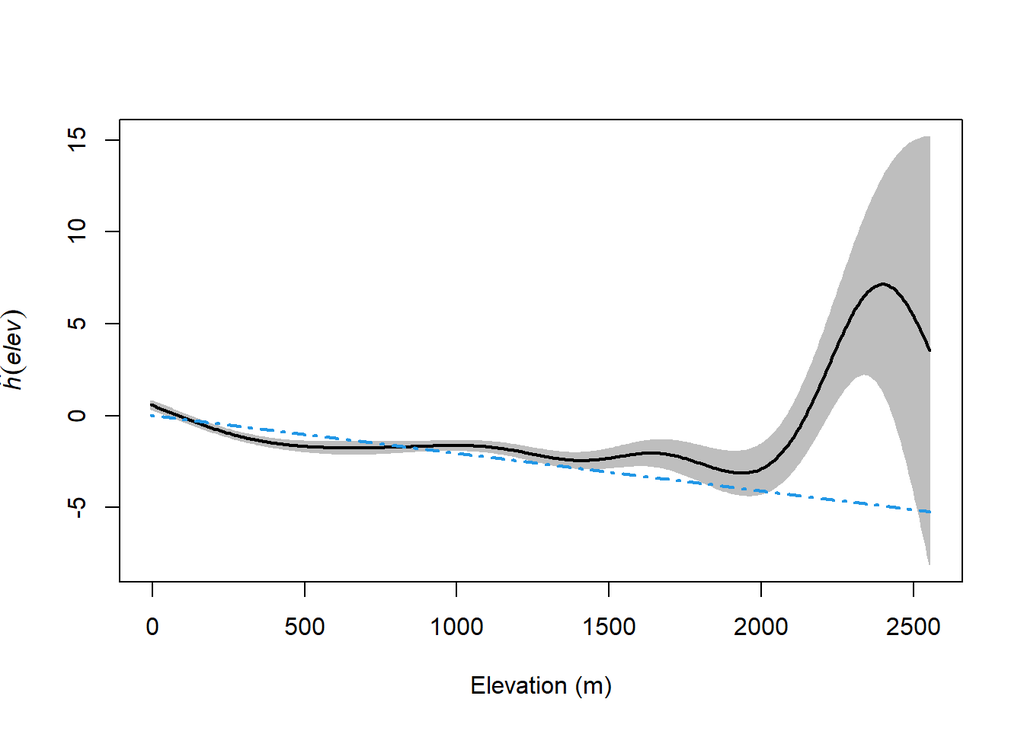

```r
#Calculate the partial residuals as a function of elevation
par_res_elev <- parres(clean_fit, "elev")

#Calculate the relative intensity as a function of cover
par_res_cover <- parres(clean_fit, "forest_cover")

#Calculate the partial residuals as a function of elevation
par_res_hfi <- parres(clean_fit, "hfi")

#Calculate the relative intensity as a function of cover
par_res_dist_water <- parres(clean_fit, "dis_water")

#Side by side plotting
plot(par_res_elev,
     legend = FALSE,
     lwd = 2,
     main = "",
     xlab = "Elevation (m)")
```

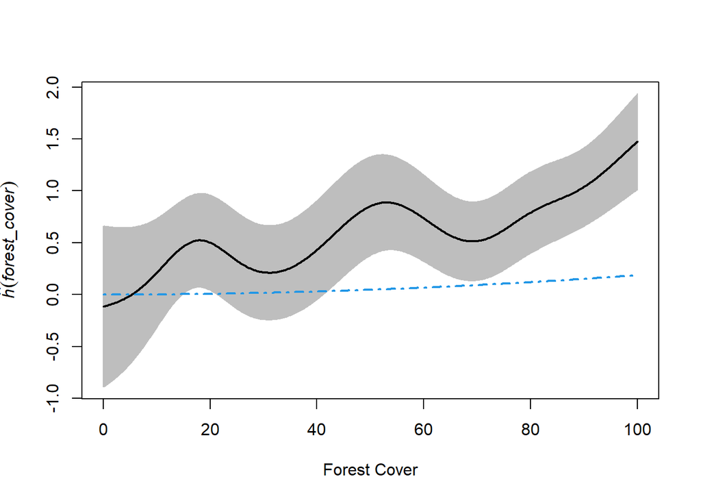

```r
plot(par_res_cover,
     legend = FALSE,
     lwd = 2,
     main = "",
     xlab = "Forest Cover")
```

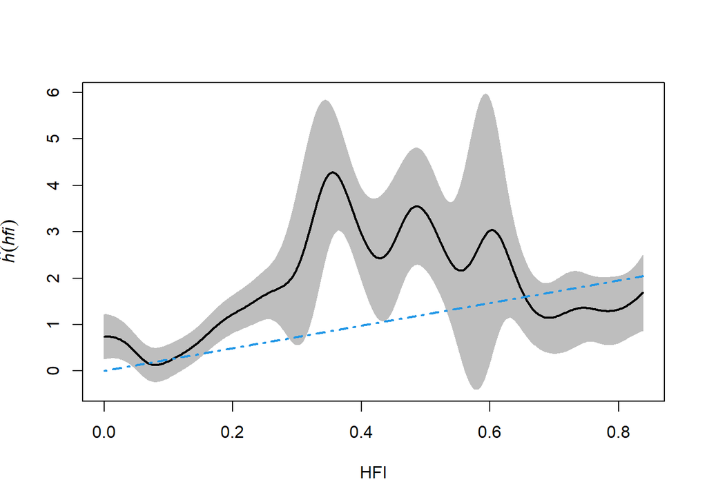

```r
plot(par_res_hfi,
     legend = FALSE,
     lwd = 2,
     main = "",
     xlab = "HFI")
```

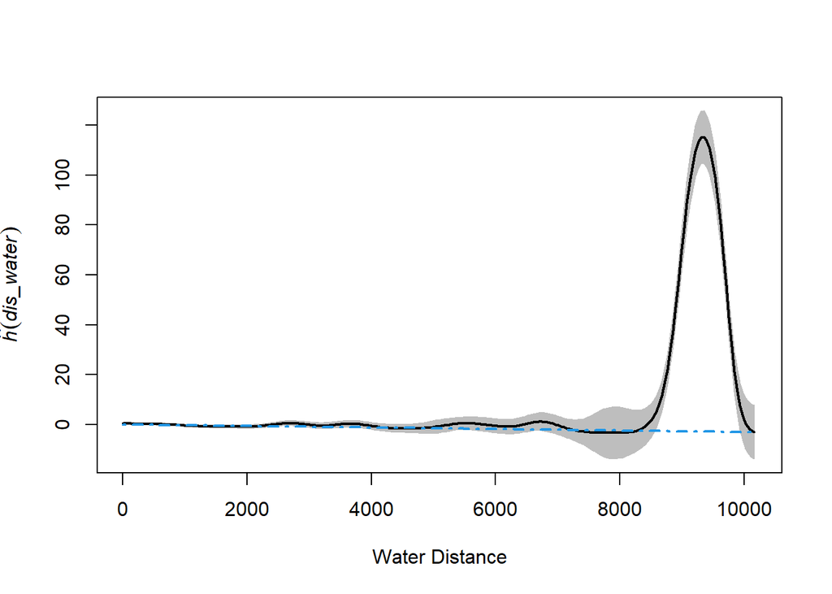

```r
plot(par_res_dist_water,
     legend = FALSE,
     lwd = 2,
     main = "",
     xlab = "Water Distance")
```

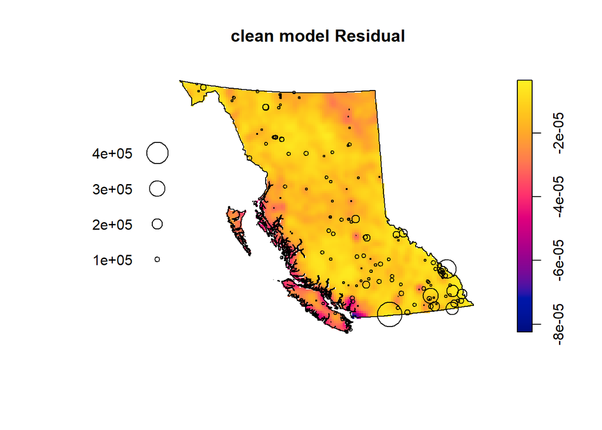

```r
residual_fit_clean = residuals(clean_fit, "pearson")

plot(residual_fit_clean, main = "clean model Residual")
```

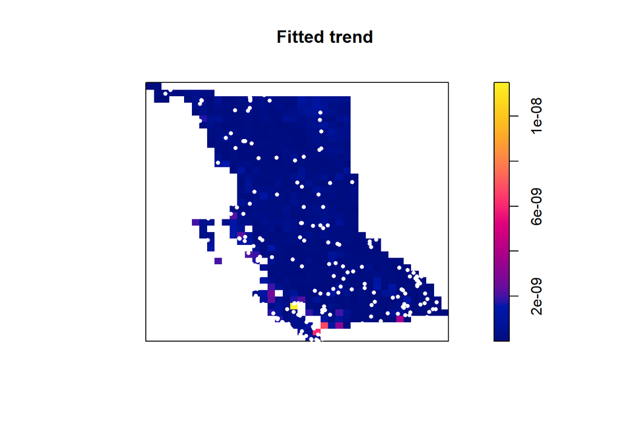

```r
#Plot the model predictions
plot(clean_fit,
     se = FALSE,
     superimpose = FALSE)
#Overlay the B. pendula locations
plot(lupus_ppp,
     pch = 16,
     cex = 0.6,
     cols = "white",
     add = TRUE)
```

- The Pearson residual plot indicates that while fitted PPM model captures some of the factors influencing wolf distribution, there is **remaining unexplained spatial variation**, particularly in areas where the model is over-predicting wolf occurrences (the regions with negative residuals). This suggests that we might consider exploring additional covariates or model structures to improve the fit and better explain the spatial patterns of wolves in these specific areas. A perfectly fitted model would ideally show residuals that are spatially random.
- The fitted model (clean_fit) suggests that the combination of environmental conditions most suitable for lupus_ppp are relatively rare and geographically concentrated in small areas in the southwest. The model predicts much lower suitability across most of the landscape. The fact that many observed points fall in areas predicted to have low intensity might indicate that the model isn’t perfectly capturing all factors influencing the distribution, potentially leading to underprediction in those specific spots.

```r
library(splines)

#Fit the PPP model
fit_spline_clean <- ppm(lupus_ppp ~ bs(elev, 7) + bs(forest_cover, 8) + bs(hfi, 9) + bs(dis_water, 8), data = list(elev = elev_clean, forest_cover = forest_cover_clean, hfi = hfi_clean, dis_water = dis_water_clean))
fit_spline_clean
```

```
## Nonstationary Poisson process
## Fitted to point pattern dataset 'lupus_ppp'
##
## Log intensity:  ~bs(elev, 7) + bs(forest_cover, 8) + bs(hfi, 9) + bs(dis_water,
## 8)
##
## Fitted trend coefficients:
##          (Intercept)         bs(elev, 7)1         bs(elev, 7)2
##         -18.72842903          -5.00262944          -3.86012630
##         bs(elev, 7)3         bs(elev, 7)4         bs(elev, 7)5
##          -4.18088903          -3.41765530          -8.12385334
##         bs(elev, 7)6         bs(elev, 7)7 bs(forest_cover, 8)1
##           3.99297626         -16.42342818          -0.07421022
## bs(forest_cover, 8)2 bs(forest_cover, 8)3 bs(forest_cover, 8)4
##           0.49626752           0.90084565           1.65289815
## bs(forest_cover, 8)5 bs(forest_cover, 8)6 bs(forest_cover, 8)7
##           0.60572033           1.50402656           0.70326507
## bs(forest_cover, 8)8          bs(hfi, 9)1          bs(hfi, 9)2
##           0.85439028          -1.00013919          -0.33803748
##          bs(hfi, 9)3          bs(hfi, 9)4          bs(hfi, 9)5
##          -0.06061538          -0.24953421           0.88841602
##          bs(hfi, 9)6          bs(hfi, 9)7          bs(hfi, 9)8
##           0.54214939           2.26436268           2.94473006
##          bs(hfi, 9)9    bs(dis_water, 8)1    bs(dis_water, 8)2
##          -0.86502164          -0.31822031          -1.10868395
##    bs(dis_water, 8)3    bs(dis_water, 8)4    bs(dis_water, 8)5
##          -0.91147178          -1.37821698          -1.11817840
##    bs(dis_water, 8)6    bs(dis_water, 8)7    bs(dis_water, 8)8
##          -0.39431519          -4.51979093          -3.52399887
##
##                          Estimate       S.E.      CI95.lo     CI95.hi Ztest
## (Intercept)          -18.72842903  0.4937099 -19.69608270 -17.7607754   ***
## bs(elev, 7)1          -5.00262944  0.5955423  -6.16987096  -3.8353879   ***
## bs(elev, 7)2          -3.86012630  0.5290560  -4.89705706  -2.8231955   ***
## bs(elev, 7)3          -4.18088903  0.4021982  -4.96918293  -3.3925951   ***
## bs(elev, 7)4          -3.41765530  0.3475380  -4.09881726  -2.7364933   ***
## bs(elev, 7)5          -8.12385334  1.4783080 -11.02128371  -5.2264230   ***
## bs(elev, 7)6           3.99297626  5.5183635  -6.82281745  14.8087700
## bs(elev, 7)7         -16.42342818 23.2802527 -62.05188508  29.2050287
## bs(forest_cover, 8)1  -0.07421022  0.6621159  -1.37193359   1.2235132
```

[output cut: 44 more lines]

```
## bs(hfi, 9)4           -0.34120135
## bs(hfi, 9)5            1.79957533
## bs(hfi, 9)6            1.23842930
## bs(hfi, 9)7            2.98989976
## bs(hfi, 9)8            2.42760200
## bs(hfi, 9)9           -0.83991516
## bs(dis_water, 8)1     -0.75924280
## bs(dis_water, 8)2     -2.46332339
## bs(dis_water, 8)3     -2.23342765
## bs(dis_water, 8)4     -3.89773800
## bs(dis_water, 8)5     -3.57668727
## bs(dis_water, 8)6     -0.25538435
## bs(dis_water, 8)7     -0.87976095
## bs(dis_water, 8)8     -0.34413679
## *** Fitting algorithm for 'glm' did not converge ***
```

```r
#Calculate the partial residuals as a function of elevation
par_res_elev <- parres(fit_spline_clean, "elev")
#Calculate the relative intensity as a function of cover
par_res_cover <- parres(fit_spline_clean, "forest_cover")
#Calculate the partial residuals as a function of elevation
par_res_hfi <- parres(fit_spline_clean, "hfi")
#Calculate the relative intensity as a function of cover
par_res_dist_water <- parres(fit_spline_clean, "dis_water")
```

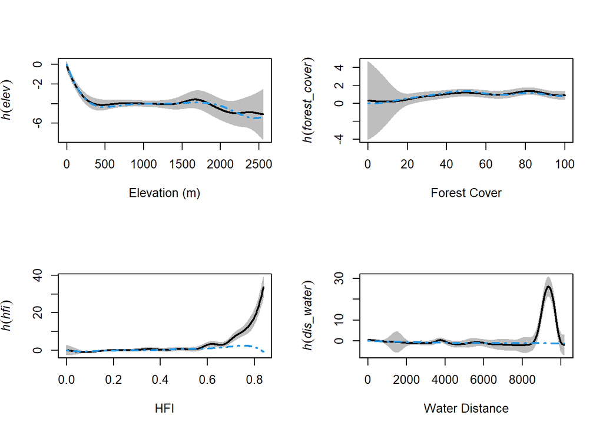

```r
par(mfrow = c(2, 2)) # Create a 2 x 2 plotting matrix
#Side by side plotting
plot(par_res_elev,
     legend = FALSE,
     lwd = 2,
     main = "",
     xlab = "Elevation (m)")
plot(par_res_cover,
     legend = FALSE,
     lwd = 2,
     main = "",
     xlab = "Forest Cover")
plot(par_res_hfi,
     legend = FALSE,
     lwd = 2,
     main = "",
     xlab = "HFI")
plot(par_res_dist_water,
     legend = FALSE,
     lwd = 2,
     main = "",
     xlab = "Water Distance")
```

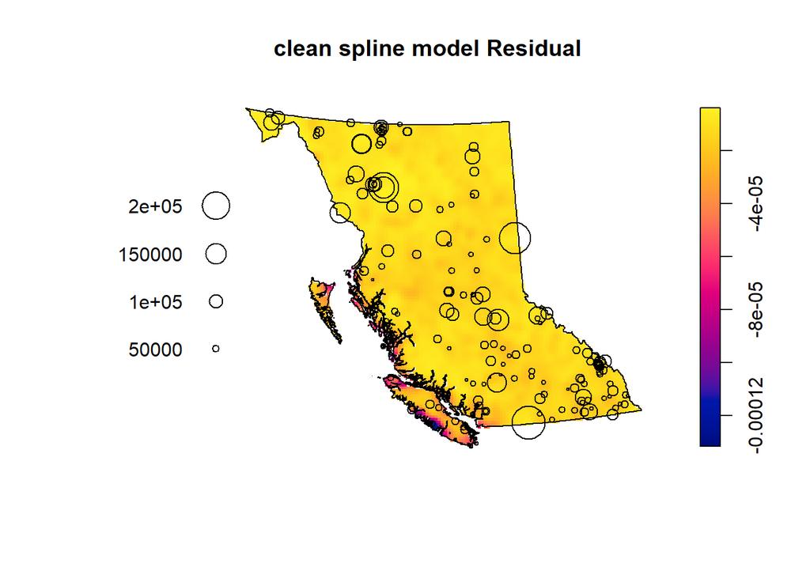

```r
residual_fit_spline_clean = residuals(fit_spline_clean, "pearson")

plot(residual_fit_spline_clean, main = "clean spline model Residual")
```

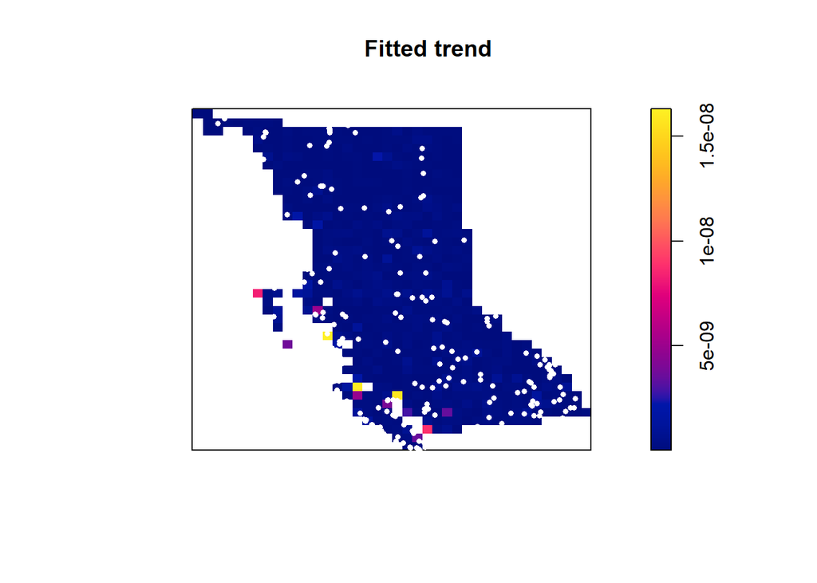

```r
#Plot the model predictions
plot(fit_spline_clean,
     se = FALSE,
     superimpose = FALSE)

#Overlay the B. pendula locations
plot(lupus_ppp,
     pch = 16,
     cex = 0.6,
     cols = "white",
     add = TRUE)
```

**Striking Similarity:** The overall spatial pattern of residuals is remarkably similar to the previous model’s (“clean model Residual”).

**Interior:** Much of the interior remains yellow/orange, indicating residuals close to zero. The spline model, like the simpler model, fits reasonably well here.

**Circles (Raw Residuals):** Similar pattern to before, with large circles (large magnitude raw residuals) concentrated in the southeast, but also some noticeable ones in the interior, suggesting localized deviations.

```r
anova(clean_fit, fit_spline_clean, test = "LRT")
```

```
## Analysis of Deviance Table
##
## Model 1: ~elev + I(forest_cover^2) + hfi + dis_water      Poisson
## Model 2: ~bs(elev, 7) + bs(forest_cover, 8) + bs(hfi, 9) + bs(dis_water, 8)   Poisson
##   Npar Df Deviance  Pr(>Chi)
## 1    5
## 2   33 28   366.08 < 2.2e-16 ***
## ---
## Signif. codes:  0 '***' 0.001 '**' 0.01 '*' 0.05 '.' 0.1 ' ' 1
```

- The Likelihood Ratio Test strongly suggests that the relationships between the intensity of wolf occurrences and covariates (elevation, forest cover, HFI, and distance to water) are likely **non-linear**. Using flexible functions like splines in our model is more appropriate for capturing these complex relationships than using simple linear terms

```r
# Apply log transformation to dis_water
dis_water_log <- log(dis_water_clean + 1)

hfi_log <- log(hfi_clean + 1)

# Fit the model with log-transformed dis_water
fit_log_with_spline_clean<- ppm(lupus_ppp ~ bs(elev, 7) + bs(forest_cover, 8) + bs(hfi_log, df = 5) + bs(dis_water_log, df = 6), data = list(elev = elev_clean, forest_cover = forest_cover_clean, hfi = hfi_log, dis_water = dis_water_log))

fit_log_with_spline_clean
```

```
## Nonstationary Poisson process
## Fitted to point pattern dataset 'lupus_ppp'
##
## Log intensity:  ~bs(elev, 7) + bs(forest_cover, 8) + bs(hfi_log, df = 5) +
## bs(dis_water_log, df = 6)
##
## Fitted trend coefficients:
##                (Intercept)               bs(elev, 7)1
##               -19.13542154                -4.94162029
##               bs(elev, 7)2               bs(elev, 7)3
##                -3.77809870                -4.12517068
##               bs(elev, 7)4               bs(elev, 7)5
##                -3.36331748                -7.85202707
##               bs(elev, 7)6               bs(elev, 7)7
##                 3.67085284               -13.29331016
##       bs(forest_cover, 8)1       bs(forest_cover, 8)2
##                -0.17924106                 0.38211973
##       bs(forest_cover, 8)3       bs(forest_cover, 8)4
##                 0.85199986                 1.54537852
##       bs(forest_cover, 8)5       bs(forest_cover, 8)6
##                 0.55353766                 1.38908472
##       bs(forest_cover, 8)7       bs(forest_cover, 8)8
##                 0.58361732                 0.77247733
##       bs(hfi_log, df = 5)1       bs(hfi_log, df = 5)2
##                -0.02930657                 1.02309334
##       bs(hfi_log, df = 5)3       bs(hfi_log, df = 5)4
##                 1.08140498                 4.70549265
##       bs(hfi_log, df = 5)5 bs(dis_water_log, df = 6)1
##                -0.25152537                -1.56307601
## bs(dis_water_log, df = 6)2 bs(dis_water_log, df = 6)3
##                 0.28578521                -1.51536967
## bs(dis_water_log, df = 6)4 bs(dis_water_log, df = 6)5
##                -0.97910872                -0.84545651
## bs(dis_water_log, df = 6)6
##                -4.49504139
##
##                                Estimate       S.E.      CI95.lo     CI95.hi
## (Intercept)                -19.13542154  0.4313024 -19.98075874 -18.2900843
## bs(elev, 7)1                -4.94162029  0.5890721  -6.09618048  -3.7870601
## bs(elev, 7)2                -3.77809870  0.5297590  -4.81640719  -2.7397902
```

[output cut: 37 more lines]

```
## bs(forest_cover, 8)5               1.08619345
## bs(forest_cover, 8)6           *   2.53666932
## bs(forest_cover, 8)7               0.96222083
## bs(forest_cover, 8)8               1.83415688
## bs(hfi_log, df = 5)1              -0.05852148
## bs(hfi_log, df = 5)2          **   2.93237658
## bs(hfi_log, df = 5)3               1.74040288
## bs(hfi_log, df = 5)4         ***   5.36133109
## bs(hfi_log, df = 5)5              -0.35348466
## bs(dis_water_log, df = 6)1        -1.48473643
## bs(dis_water_log, df = 6)2         0.46811981
## bs(dis_water_log, df = 6)3   ***  -5.52626488
## bs(dis_water_log, df = 6)4        -1.70116482
## bs(dis_water_log, df = 6)5        -0.55418285
## bs(dis_water_log, df = 6)6        -1.02117279
```

```r
#Calculate the partial residuals as a function of elevation
par_res_elev <- parres(fit_log_with_spline_clean, "elev")
#Calculate the relative intensity as a function of cover
par_res_cover <- parres(fit_log_with_spline_clean, "forest_cover")
#Calculate the partial residuals as a function of elevation
par_res_hfi <- parres(fit_log_with_spline_clean, "hfi_log")
#Calculate the relative intensity as a function of cover
par_res_dist_water <- parres(fit_log_with_spline_clean, "dis_water_log")
```

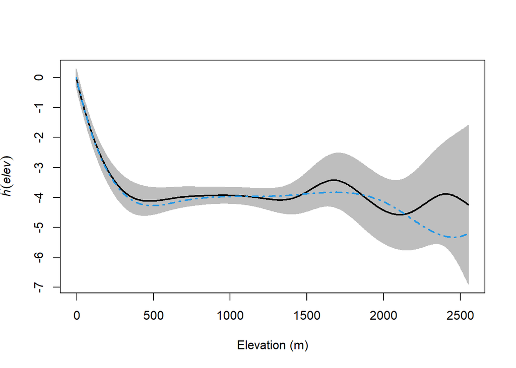

```r
#Side by side plotting
plot(par_res_elev,
     legend = FALSE,
     lwd = 2,
     main = "",
     xlab = "Elevation (m)")
```

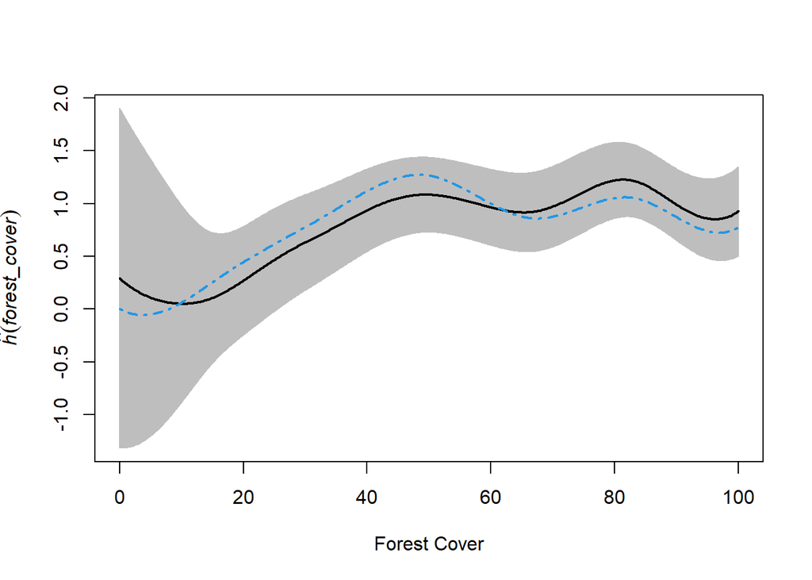

```r
plot(par_res_cover,
     legend = FALSE,
     lwd = 2,
     main = "",
     xlab = "Forest Cover")
```

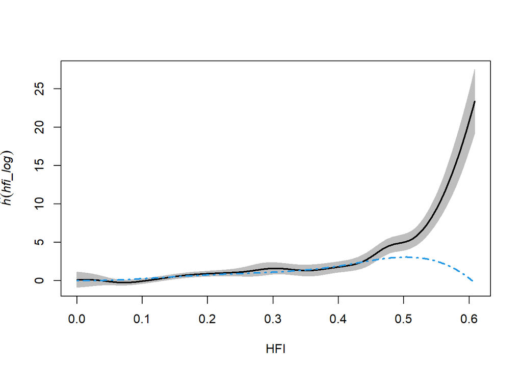

```r
plot(par_res_hfi,
     legend = FALSE,
     lwd = 2,
     main = "",
     xlab = "HFI")
```

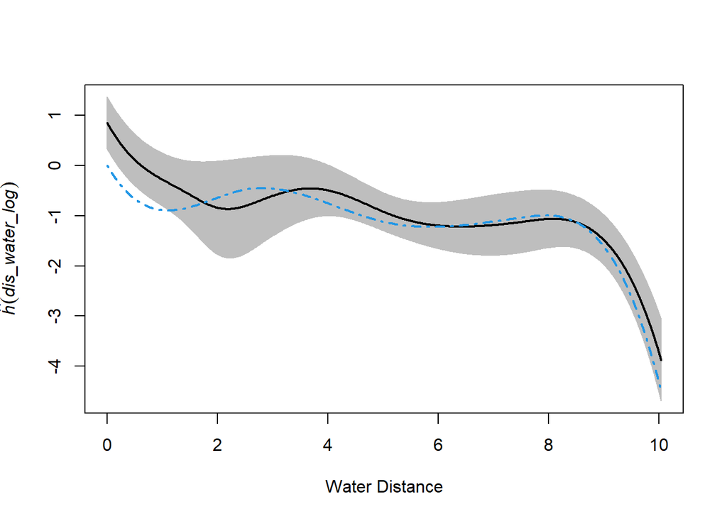

```r
plot(par_res_dist_water,
     legend = FALSE,
     lwd = 2,
     main = "",
     xlab = "Water Distance")
```

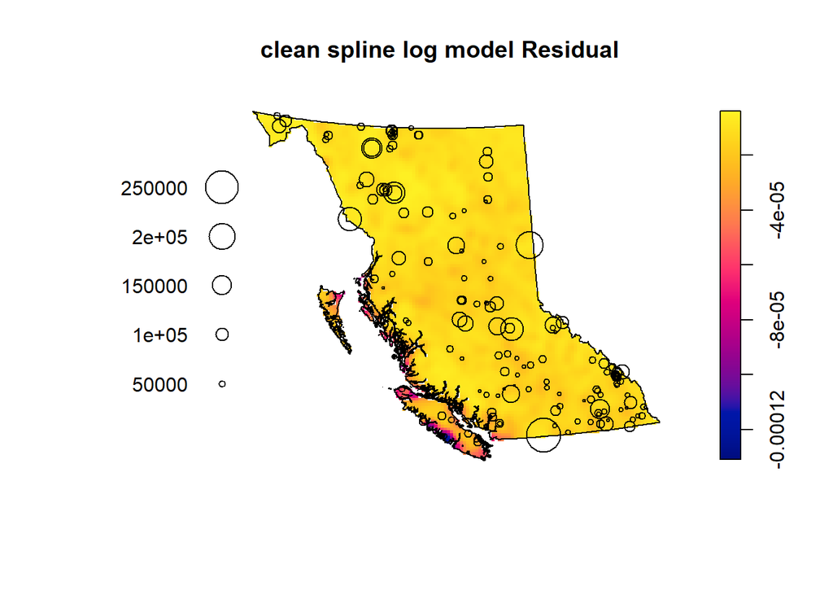

```r
residual_fit_spline_log_clean = residuals(fit_log_with_spline_clean, "pearson")

plot(residual_fit_spline_log_clean, main = "clean spline log model Residual")
```

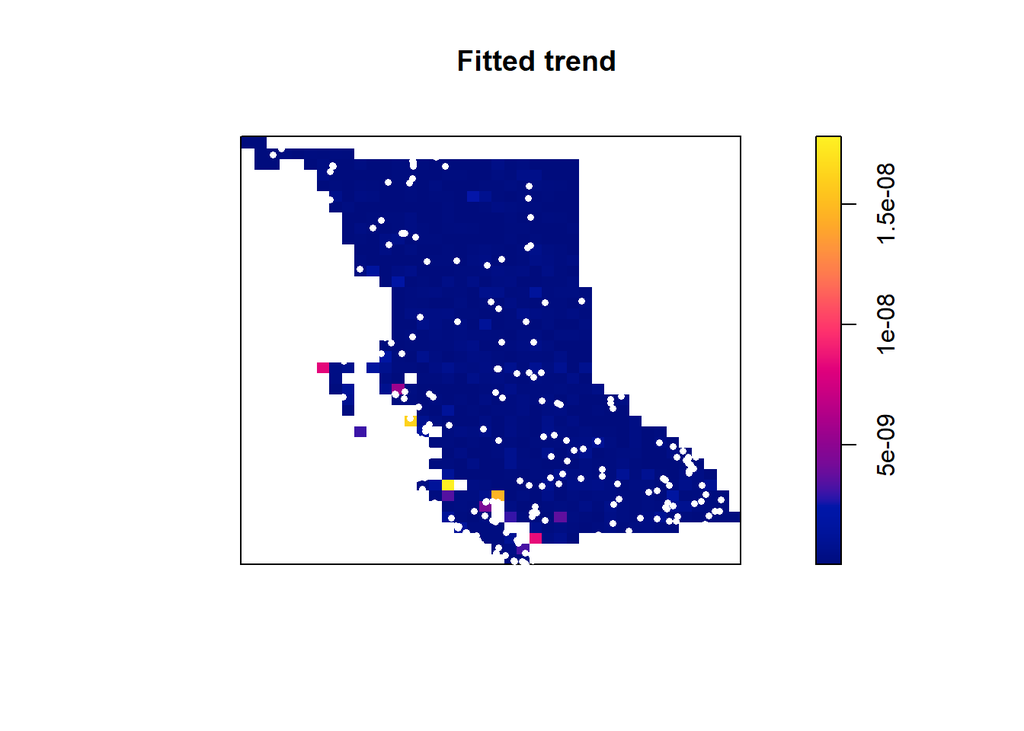

```r
#Plot the model predictions
plot(fit_log_with_spline_clean,
     se = FALSE,
     superimpose = FALSE)

#Overlay the B. pendula locations
plot(lupus_ppp,
     pch = 16,
     cex = 0.6,
     cols = "white",
     add = TRUE)
```

**Comparison to Previous Spline Model:** The most striking observation is how incredibly similar this residual plot looks to the previous one (“clean spline model Residual”) that didn’t use the log transformations for hfi and dis_water.

**Circles:** The pattern and relative sizes of the circles representing raw residuals also appear unchanged.

**Predominantly Low Intensity:** Similar to the trend plot from the simpler `clean_fit model`, the vast majority of the study area is dark blue/purple. The model predicts a very low probability of point occurrence across most of the landscape.

**Localized Hotspots:** Small areas, primarily concentrated in the southwest (coastal/border region), show higher predicted intensities (magenta/yellow). These are where the model identifies the most favorable conditions based on the specific covariate values and the fitted spline relationships.

**Observed Data (White Dots):** The overlay shows that while some points fall near the predicted higher-intensity areas, many points are located within the extensive dark blue regions where the model predicts very low intensity.

**Overall Conclusion:** - Using splines and log transformations for some covariates did not fundamentally change the model’s overall prediction of the spatial trend compared to the simpler model.

- The model consistently predicts that the conditions suitable for lupus_ppp points are rare and concentrated in small areas (primarily southwest).
- It predicts very low suitability across most of the region.
- The discrepancy between the predicted low intensity and the presence of observed points in large parts of the interior persists.

**Connecting to the Residual Plot:** This fitted trend plot is consistent with the corresponding “clean spline log model Residual” plot.

```r
anova(clean_fit, fit_spline_clean, test = "LRT")
```

```
## Analysis of Deviance Table
##
## Model 1: ~elev + I(forest_cover^2) + hfi + dis_water      Poisson
## Model 2: ~bs(elev, 7) + bs(forest_cover, 8) + bs(hfi, 9) + bs(dis_water, 8)   Poisson
##   Npar Df Deviance  Pr(>Chi)
## 1    5
## 2   33 28   366.08 < 2.2e-16 ***
## ---
## Signif. codes:  0 '***' 0.001 '**' 0.01 '*' 0.05 '.' 0.1 ' ' 1
```

**Conclusion:** - The extremely small p-value leads to a strong rejection of the null hypothesis that the simpler model (Model 1) is adequate.

- There is highly statistically significant evidence that the spline model (fit_spline_clean, Model 2) provides a substantially better fit to the data than the model using only simple linear and quadratic terms (clean_fit, Model 1).

```r
anova(fit_log_with_spline_clean, fit_spline_clean, test = "LRT")
```

```
## Analysis of Deviance Table
##
## Model 1: ~bs(elev, 7) + bs(forest_cover, 8) + bs(hfi_log, df = 5) + bs(dis_water_log, df = 6)     Poisson
## Model 2: ~bs(elev, 7) + bs(forest_cover, 8) + bs(hfi, 9) + bs(dis_water, 8)   Poisson
##   Npar Df Deviance Pr(>Chi)
## 1   27
## 2   33  6   1.8927   0.9293
```

**Conclusion:** - The p-value (0.9293) is very large (much larger than typical significance levels like 0.05). Therefore, **we fail to reject the null hypothesis**.

- This means there is **no statistically significant evidence** to suggest that Model 2 (splines on original `hfi`/`dis_water` with higher df) fits the data significantly better than Model 1 (splines on log-transformed `hfi`/`dis_water` with lower df).
- Log-transforming `hfi` and `dis_water` (and adjusting the spline complexity slightly) did **not** result in a significantly worse fit compared to using splines on the original scales with higher complexity. Neither model is statistically superior to the other based on this test.

```r
library(ape)
library(fields)
library(gstat)
coords <- cbind(lupus_ppp$x, lupus_ppp$y)

elev_values <- elev_clean[lupus_ppp]


dist_mat <- fields::rdist(coords)

# Inverse distance weights (avoid division by zero)
#inv_dist <- 1 / dist_mat

#diag(inv_dist) <- 0  # set self-distances to 0 (avoid Inf)


ape::Moran.I(elev_values, weight = dist_mat)
```

```
## $observed
## [1] -0.1709932
##
## $expected
## [1] -0.003401361
##
## $sd
## [1] 0.002226371
##
## $p.value
## [1] 0
```

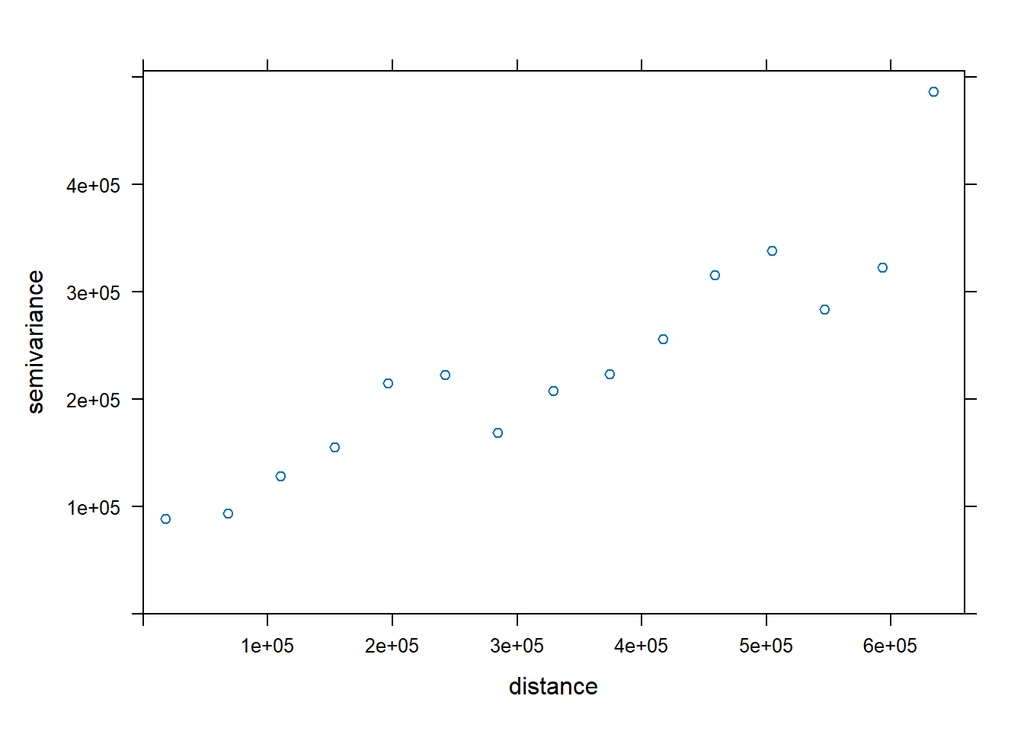

```r
# Extract coordinates from lupus_ppp
coords <- coords(lupus_ppp)

# Extract elevation values at those locations
elev_values <- elev_clean[lupus_ppp]

# Combine into a data frame
DATA <- data.frame(Z_s = elev_values,
                   x = coords[,1],
                   y = coords[,2])

# Convert to SpatialPointsDataFrame
sp::coordinates(DATA) <- ~x+y

# Calculate empirical variogram
vg <- gstat :: variogram (Z_s ~ 1, data = DATA )
# object of class = " gstatVariogram "
plot ( vg )
```

```r
# Fit linear correlation model
fit.linear <- fit.variogram (vg , vgm ("Lin"))
fit.linear
```

```
##   model    psill    range
## 1   Nug  80179.7      0.0
## 2   Lin 405202.5 904308.3
```

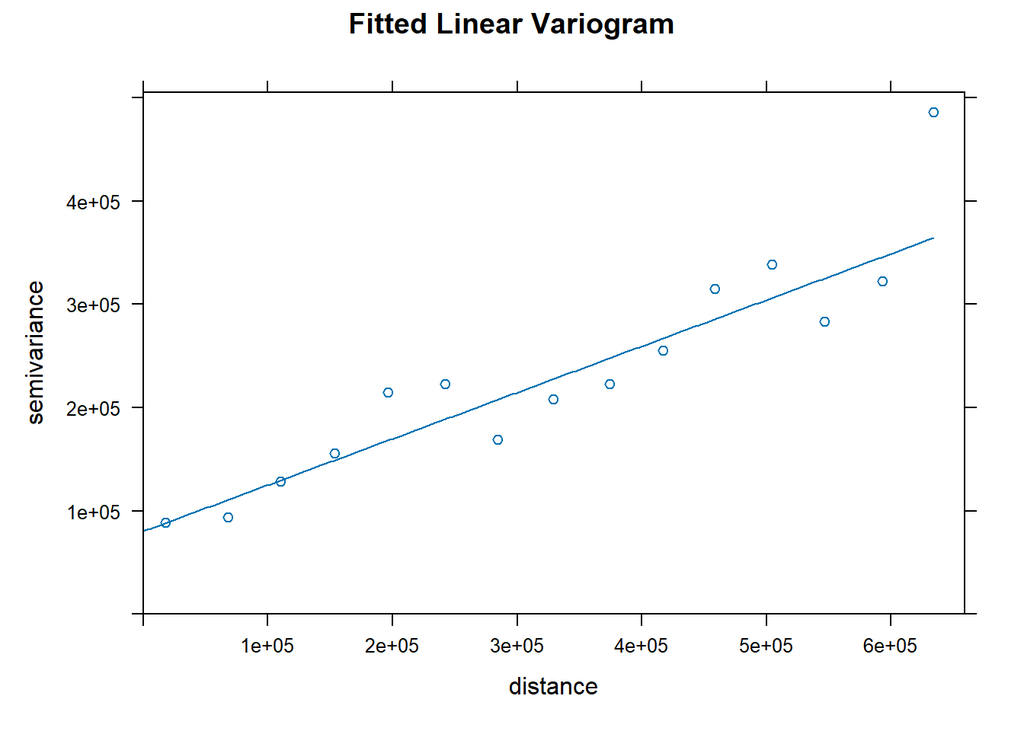

```r
# Plot the empirical and fitted variogram
plot(vg, fit.linear, main = "Fitted Linear Variogram")
```

```r
fit.spherical <- fit.variogram(vg, vgm("Sph"))
fit.spherical
```

```
##   model      psill    range
## 1   Nug   80711.69        0
## 2   Sph 3165637.01 10511360
```

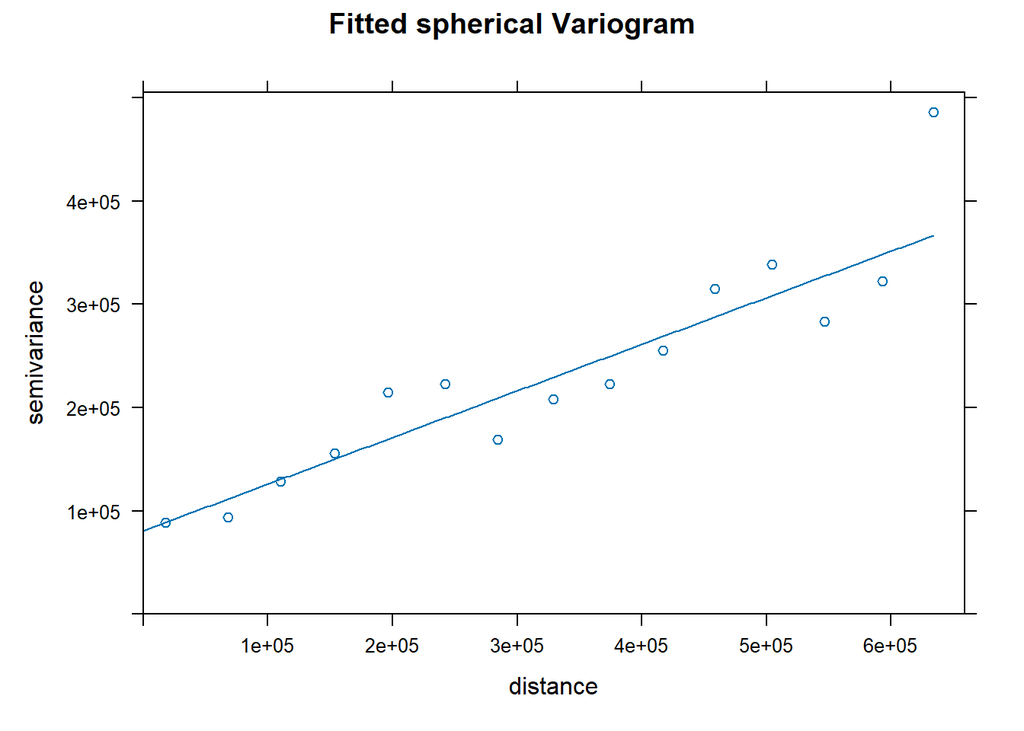

```r
plot(vg, fit.spherical, main = "Fitted spherical Variogram")
```

```r
# Fit Gaussian correlation model
fit.Gaussian <- fit.variogram (vg , vgm ("Gau"))
fit.Gaussian
```

```
##   model     psill    range
## 1   Nug  87523.19      0.0
## 2   Gau 217149.67 267593.7
```

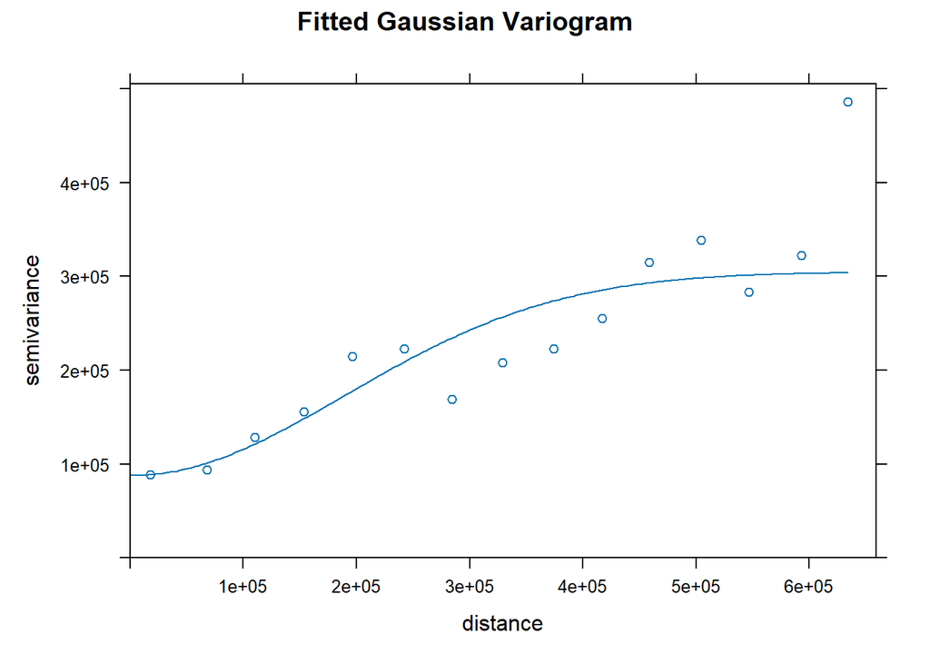

```r
plot(vg, fit.Gaussian, main = "Fitted Gaussian Variogram")
```

```r
# Fit exponential correlation model
fit.exponential <- fit.variogram (vg , vgm ("Exp"))
fit.exponential
```

```
##   model       psill    range
## 1   Nug    82223.28        0
## 2   Exp 26395651.35 55207406
```

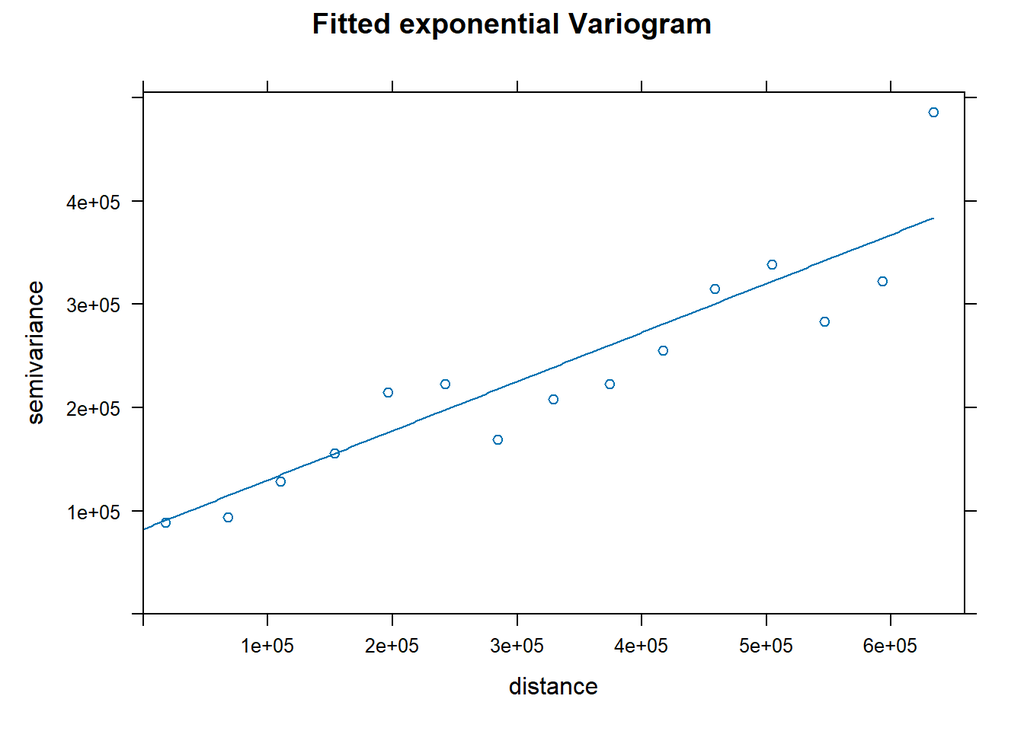

```r
plot(vg, fit.exponential, main = "Fitted exponential Variogram")
```

```r
# Fit nugget only model
fit.nugget <- fit.variogram (vg , vgm ("Nug"))
fit.nugget
```

```
##   model    psill range
## 1   Nug 94037.11     0
```

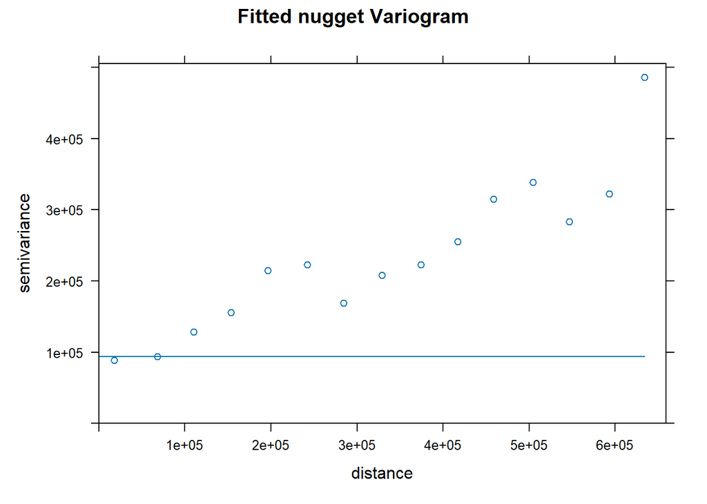

```r
plot(vg, fit.nugget, main = "Fitted nugget Variogram")
```

```r
# Initialize list to store results
model_list <- list(
  spherical = fit.spherical,
  linear = fit.linear,
  Gaussian = fit.Gaussian,
  exponential = fit.exponential,
  nugget = fit.nugget
)

# Extract SSErr safely
model_names <- c()
sse_values <- c()

for (name in names(model_list)) {
  fit <- model_list[[name]]
  sse <- tryCatch(attr(fit, "SSErr"), error = function(e) NA)

  if (!is.null(sse) && !is.na(sse)) {
    model_names <- c(model_names, name)
    sse_values <- c(sse_values, sse)
  }
}

# Create and order results
results <- data.frame(model = model_names, SSErr = sse_values)
results <- results[order(results$SSErr), ]

# Print
print(results)
```

```
##         model     SSErr
## 2      linear  365.5100
## 1   spherical  366.4289
## 4 exponential  420.5888
## 3    Gaussian  450.9952
## 5      nugget 4709.4598
```

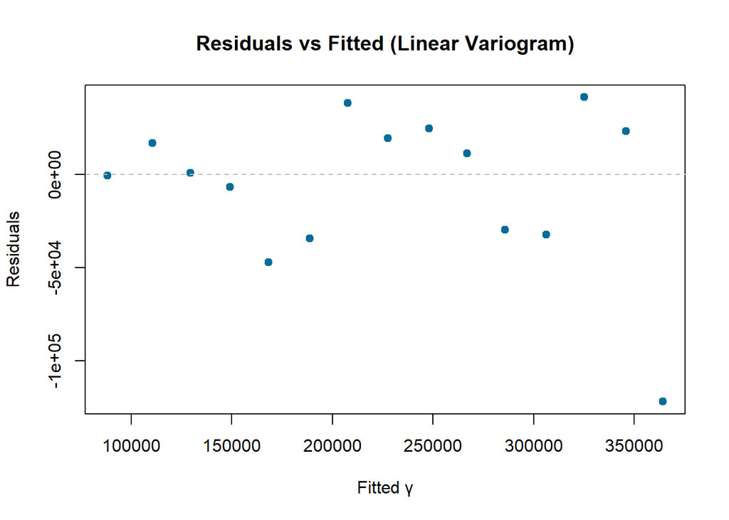

```r
# Get fitted values from the linear variogram model
fitted <- variogramLine(fit.linear,
                        maxdist = max(vg$dist),
                        dist_vector = vg$dist)

# Calculate residuals
residuals <- fitted$gamma - vg$gamma

# Visualize the residuals
plot(residuals ~ fitted$gamma,
     main = "Residuals vs Fitted (Linear Variogram)",
     xlab = "Fitted γ",
     ylab = "Residuals",
     pch = 19,
     col = "#046C9A")
abline(h = 0, lty = 2, col = "gray")
```